# weather_taxi_bike

FC

12/10/2021

## Visualization

```r
library(knitr)
library(tidyverse)
library(dplyr)
library(tidyverse)
library(data.table)
```

```r
library(patchwork)

knitr::opts_chunk$set(
  fig.width = 6,
  fig.asp = .6,
  out.width = "90%"
)

theme_set(theme_minimal() + theme(legend.position = "bottom"))

options(
  ggplot2.continuous.colour = "viridis",
  ggplot2.continuous.fill = "viridis"
)

scale_colour_discrete = scale_colour_viridis_d
scale_fill_discrete = scale_fill_viridis_d
```

```r
# Read velocity dataset.
test_df <- read_csv("./data/test_dt_V1.csv")
# Select data with time range
test_df <- setDT(test_df)
test_df <- test_df[, date := format(as.Date(tpep_pickup_datetime),"%Y-%m-%d")]
test_df <- test_df[date >= "2020-06"][date < "2021-06"]

# Read weather dataset.
weather_df <- read_csv("./data/manhattan_weather.csv")
# Data clean
test_df <-
  test_df %>%
  mutate(date = format(tpep_pickup_datetime, format = '%Y-%m-%d')) %>%
  mutate(date = as.Date(date))

# Join table
weather_transport_df <-
  left_join(test_df, weather_df, by = "date") %>%
  dplyr::select(trip_distance, type, month, velocity, date, awnd, prcp, snwd, tmax, tmin, tsun) %>%
  mutate(type = as.factor(type))
```

```r
# wind speed (mm) vs velocity
weather_transport_df_wv <-
  weather_transport_df %>%
  drop_na(awnd, velocity) %>%
  group_by(type, awnd) %>%
  summarize(v_mean = mean(velocity))
```

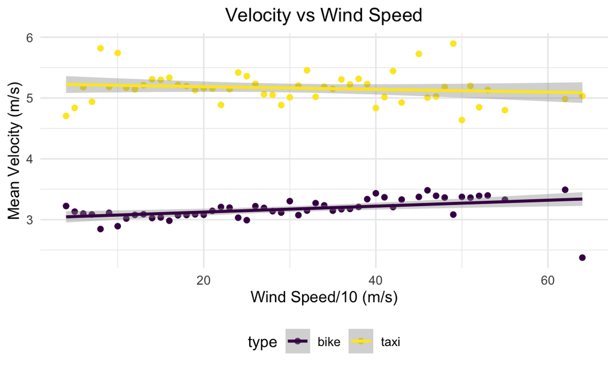

```r
# Draw plot with velocity and precipitation.
  ggplot(weather_transport_df_wv, aes(x = awnd, y = v_mean, group = type, colour = type)) +
  geom_point(aes(colour = type)) +
  geom_smooth(method = lm) +
  labs(title = "Velocity vs Wind Speed",
         x = "Wind Speed/10 (m/s)",
         y = "Mean Velocity (m/s)") +
  theme(plot.title = element_text(hjust = 0.5))
```

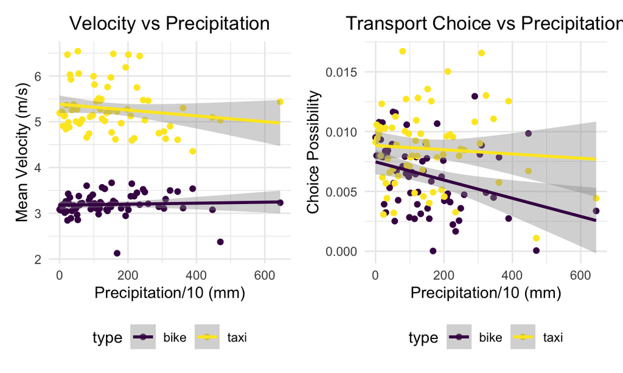

```r
# Drawing plot
# Precipitation(mm) vs velocity
weather_transport_df_sp <-
  weather_transport_df %>%
  drop_na(prcp, velocity) %>%
  group_by(type, prcp) %>%
  summarize(v_mean = mean(velocity))
# Draw plot with velocity and precipitation.
prcp_vel <-
  ggplot(weather_transport_df_sp, aes(x = prcp, y = v_mean, group = type, colour = type)) +
  geom_point(aes(colour = type)) +
  geom_smooth(method = lm) +
  labs(title = "Velocity vs Precipitation",
         x = "Precipitation/10 (mm)",
         y = "Mean Velocity (m/s)") +
  theme(plot.title = element_text(hjust = 0.5))

# Precipitation(mm) vs transportation choice
weather_transport_df_pt <-
  weather_transport_df %>%
  group_by(type, prcp, date) %>%
  summarise(n_obs = n()) %>%
  group_by(type, prcp) %>%
  summarize(n_mean = mean(n_obs))
# Draw plot: precipitation vs transportation choice.
prcp_trans <-
  ggplot(weather_transport_df_pt, aes(x = prcp, y = n_mean/sum(n_mean), group = type, colour = type)) +
  geom_point(aes(color = type)) +
  geom_smooth(method = lm) +
  labs(title = "Transport Choice vs Precipitation",
         x = "Precipitation/10 (mm)",
         y = "Choice Possibility") +
  theme(plot.title = element_text(hjust = 0.5))
prcp_vel + prcp_trans
```

Velocity could be regarded as one parameter to judge the flow of a transportation. Obviously from the plots showing the connection between the velocity and the mode of transport, the velocity of taxi are faster to bike on average. And the light to moderate rain (<30 mm), precipitation seems have no impact to the velocity, especially while taking a look at bike data. That might because though raining will make road more slippery, it also has washing effect to environment and other effects. The combination of all effects make velocity nearly stay the same. Moreover, the more amount of rain is, the slower the traffic it would be, the less people would choose to travel and it is more likely to choose taxi while weather condition getting even worse compared to riding. That might because a heavy rain might possibly affect drivers and riders visibility, thus decreases the vehicle speed and affects travel choice.

```r
# popular of transportation vs month
weather_transport_df_tm <-
  weather_transport_df %>%
  mutate(month = as.factor(month)) %>%
  group_by(type, month) %>%
  summarise(n_obs = n())
```

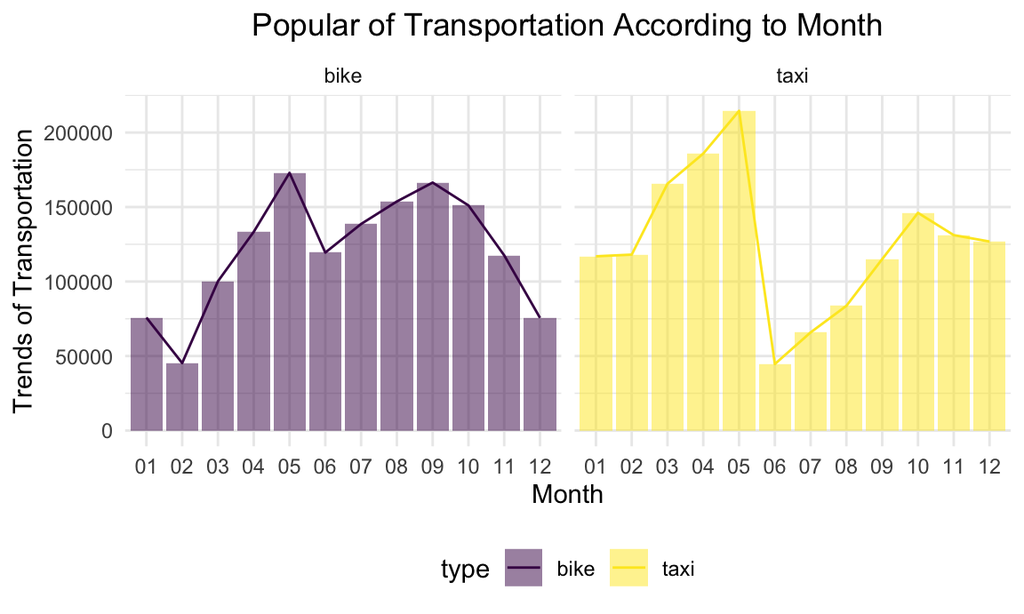

```r
ggplot(weather_transport_df_tm, aes(x = month, y = n_obs, group = type, fill = type)) +
  geom_bar(stat = "identity", alpha = 0.5) +
  geom_line(aes(color = type)) +
  facet_grid(.~type) +
  labs(title = "Popular of Transportation According to Month",
         x = "Month",
         y = "Trends of Transportation") +
  theme(plot.title = element_text(hjust = 0.5))
```

The trends for people choose to travel outside are generally similar no matter using bikes or cabs. But it exists a more significant drop for choosing taxi during the June and less people ride bikes during Dec and Feb. After analyzing the possible casuals, June is the month for students within NYU start their Summer Vacations. So the traffic pressure has a visualized decrease with more people still live in NYU. And for people, especially students, who still live in NYU, they do not have the need to commute in a hurry. Also, with the temperature getting colder and colder, people will prefer more stay at home comparing to traveling and less possibility for them to riding bikes outside. The temperature of the weather could be a confounder to transport choice and month model, but not for special month June.

```r
# High Temperature vs transportation choice.
weather_transport_df_htn <-
  weather_transport_df %>%
  mutate(month = as.factor(month)) %>%
  group_by(type, tmax) %>%
  summarise(n_obs = n())
```

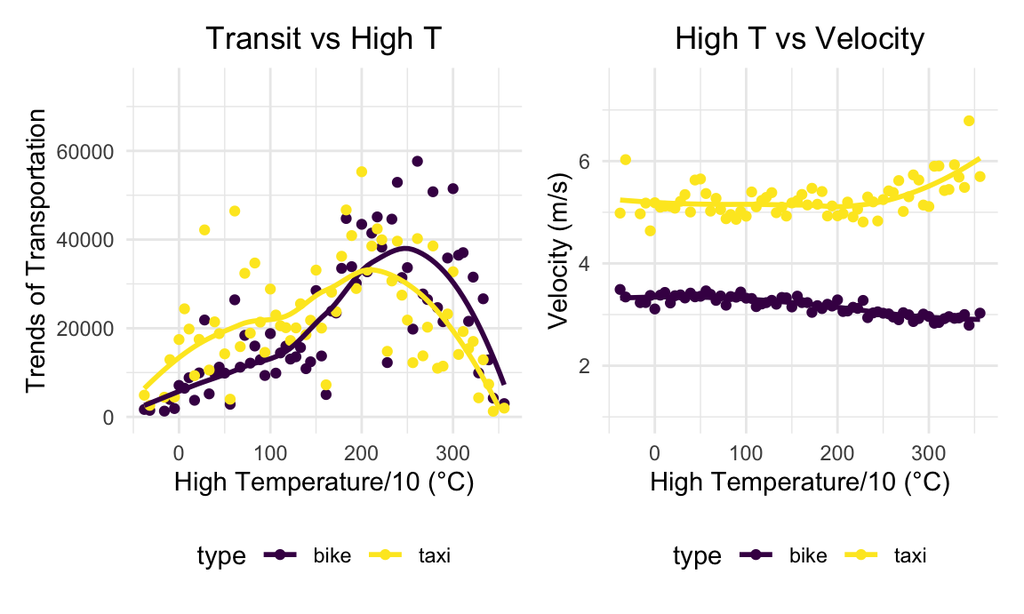

```r
ht_trans <- ggplot(weather_transport_df_htn, aes(x = tmax, y = n_obs, group = type, colour = type)) +
  geom_point(aes(color = type)) +
  geom_smooth(se = FALSE) +
  labs(title = "Transit vs High T",
         x = "High Temperature/10 (°C)",
         y = "Trends of Transportation") +
  theme(plot.title = element_text(hjust = 0.5)) +
  scale_y_continuous(limits = c(0, 7.5e+04))

# High Temperature vs velocity.
weather_transport_df_htv <-
  weather_transport_df %>%
  group_by(type, tmax) %>%
  summarise(v_avg = mean(velocity))
ht_vel <- ggplot(weather_transport_df_htv, aes(x = tmax, y = v_avg, group = type, colour = type)) +
  geom_point(aes(color = type)) +
  geom_smooth(se = FALSE) +
  labs(title = "High T vs Velocity",
         x = "High Temperature/10 (°C)",
         y = "Velocity (m/s)") +
  theme(plot.title = element_text(hjust = 0.5)) +
  scale_y_continuous(limits = c(1, 7.5))

ht_trans + ht_vel
```

```r
# Low Temperature vs transportation choice.
weather_transport_df_ltn <-
  weather_transport_df %>%
  group_by(type, tmin) %>%
  summarise(n_obs = n())
```

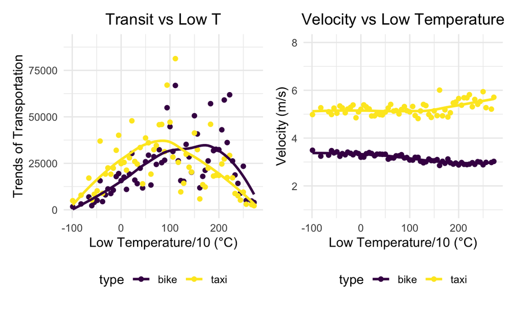

```r
lt_trans <- ggplot(weather_transport_df_ltn, aes(x = tmin, y = n_obs, group = type, colour = type)) +
  geom_point(aes(color = type)) +
  geom_smooth(se = FALSE) +
  labs(title = "Transit vs Low T",
         x = "Low Temperature/10 (°C)",
         y = "Trends of Transportation") +
  theme(plot.title = element_text(hjust = 0.5)) +
  scale_y_continuous(limits = c(0, 9e+04))

# Low Temperature vs velocity.
weather_transport_df_ltv <-
  weather_transport_df %>%
  group_by(type, tmin) %>%
  summarise(v_avg = mean(velocity))
lt_vel <- ggplot(weather_transport_df_ltv, aes(x = tmin, y = v_avg, group = type, colour = type)) +
  geom_point(aes(color = type)) +
  geom_smooth(se = FALSE) +
  labs(title = "Velocity vs Low Temperature",
         x = "Low Temperature/10 (°C)",
         y = "Velocity (m/s)") +
  theme(plot.title = element_text(hjust = 0.5)) +
  scale_y_continuous(limits = c(1, 8))

lt_trans + lt_vel
```

The connection between transport choice, popularity, velocity and the temperature are showing similar trends, considering both the highest and lowest temperature within a day. It could be concluded that people are more willing to travel outside under the moderate temperature, the higher, lower or even extreme temperature the weather is, the less potential likelihood that people will go outside and use the transport. It also comes an interesting phenomenon that taxi tends to run faster and bike runs slower with the temperature increase. The faster of the taxi could because of the decrease of the traffic pressure and this effect is more obvious compared to snow effect while riders tend to drive slower for getting warmer and slower wind speed.

```r
# lm_velocity <-
#   weather_transport_df %>%
#   sample_frac(0.0001) %>%
#   filter(type == "bike") %>%
#   mutate(month = as.factor(month)) %>%
#   drop_na() %>%
#   dplyr::select(-date) %>%
#   as_tibble() %>%
#   lm(velocity ~ trip_distance + month + awnd + prcp + snwd)
```